# act_report

## Report: act_report

### Background

- This report is a continuation of the Wrangling and Analyze Data project. Last part resulted in a combination of wrangled data. The result is used in the following steps for analysis and visualization. Insights and patterns are derived based on the merged data.

```python
#load Python libraries to set up processing environment
import pandas as pd
from matplotlib import pyplot as plt
```

```python
#restore the csv file from the wrangling step
twitter_image_tweet=pd.read_csv('twitter_archive_master.csv')
```

### Insight 1:

- The tweet archive data comes with rating_numerator and rating denominator. That gives a rating for each dog type predicted by the image data. Below snippet groups data by dog type and count the number of ratings each type received. Then rank the dog type by descending order (from high to low).
- These five types of dog gathered the highest counts of ratings: Golden_Retriever, Labrador_Retriever, Pembroke, Chihuahua, and Pug.

```python
#The 5 dog types that receive the most counts in ratings
twitter_image_tweet['rating']=twitter_image_tweet.rating_numerator / twitter_image_tweet.rating_denominator
twitter_image_tweet.groupby("p1")["rating"].count().nlargest(5)
```

```
p1
Golden_Retriever      137
Labrador_Retriever     94
Pembroke               88
Chihuahua              78
Pug                    54
Name: rating, dtype: int64
```

### Insight 2:

- Different dog stages-doggo, pupper, puppo, and floofer-are part of the DoggoLingo (https://en.wikipedia.org/wiki/DoggoLingo). This internet language is used by dog owners to express the thoughts and actions of dogs in cutesy, humorous ways. It is made up of deliberated misspellings and onomatopoeias words like "smol" (tiny and cute puppy), "teef" (for teeth), or "bork" (for bark). To better understand the insights, it helps to know the meanings or common definitions of different dog stages:
  - Doggo: an affectionate term for a dog. A big old pupper is a doggo.
  - Pupper: a smol doggo or a puppy.
  - Puppo: a slang term for puppy.
  - Floofer: A big old doggo with an abundance of fluffy fur – like the Tibetan Mastiff! (source: [https://www.npr.org/sections/alltechconsidered/2017/04/23/524514526/dogs-are-doggos-an-internet-language-built-around-love-for-the-puppers] [https://www.tastefullyoffensive.com/2017/07/the-difference-between-doggos-puppers-and-woofers/], [https://zippypaws.com/blog/doggolingo-101-internet-language-of-the-dogs/])
- The result suggested doggo has the highest retweet counts of 506,726 from dog lovers. Next one is followed by pupper of 478,883. However, we can look at the counts from a different angle. If we define tiny, small dogs loosely as pupper or puppo, their combined counts of 621,310 are much higher than doggo's or the combination of doggo and old, fluffy floofer (541,507).

```python
#What dog stage has the largest retweet counts?
twitter_image_tweet.groupby('dog_stage')['retweet_count'].sum().nlargest(5)
```

```
dog_stage
doggo      506726
pupper     478883
puppo      142427
floofer     34781
Name: retweet_count, dtype: int64
```

### Insight 3:

```python
#Which five dog type receive the most favorite_counts?
twitter_image_tweet.groupby('p1')['favorite_count'].sum().nlargest(5)
```

```
p1
Golden_Retriever      1693475
Labrador_Retriever    1116811
Pembroke               994755
Chihuahua              673526
Samoyed                542991
Name: favorite_count, dtype: int64
```

### Visualization

- This plot shows the distribution of dog type: the number of tweets predicted the corresponding type will determine their order in this ranking. Here's the order: Golden Retriever, Labrador Retriever, Pembroke, Chihuahua, Pug, Chow, Semoyed, Pomeranian, Toy Poodle, Malamute.

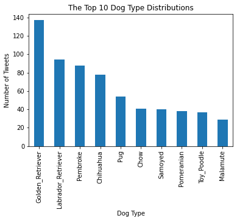

```python
#This plot shows the top 10 dog type distributions

twitter_image_tweet["p1"].value_counts()[:10].plot(kind='bar')
plt.title("The Top 10 Dog Type Distributions")
plt.xlabel("Dog Type")
plt.ylabel("Number of Tweets")
```

### Conclusion

- Golden Retriever is the type of dog gathered the most ratings
- Doggo received the most retweet counts from dog lovers
- Golden Retriever is the dog type favored by most raters